# 36-315 Homework 9, Fall 2021

SOLUTIONS

Due Tuesday, November 9 2021 (11:59pm ET) on Gradescope

# Homework 9: Maps and Spatial Data

# Problem 1: Mapping Flight Numbers, and [Kriging](https://en.wikipedia.org/wiki/Danie_G._Krige) (40 points)

In this problem, you’re going to work with a dataset on airports across the world, which we have been working with this week (see `R` demos from Lecturs 18 and 19 on Canvas). In those demos, we plotted airport data for the United States. Here is the code to load in the airports dataset we’ll use for this problem:

```r
airportD = read.csv("https://raw.githubusercontent.com/zjbranson/315Fall2021/main/airportD.csv")
```

This dataset contains the number of departing flights for all major airports in the world. You should revisit the lecture demos to understand what this dataset is. But in short, each row of `airportD` corresponds to an airport in the world; for each airport, we have information about its city and country, its latitude and longitude location, its three-letter code (`IATA_FAA`), and the number of flights departing from that airport at a given time (`flights`).

1. (10pts) Pick a country that is *not* the United States. The `airportD` dataset contains airports from all over the world, so you can pick anywhere in the world. For this part, all you have to do is create a map of the country you are focusing on for this problem. To do this, first create a vector with `left`, `bottom`, `right`, and `top`, defining the minimum/maximum latitude and longitude of your map, and then use the `get_stamenmap()` function and the `ggmap()` function to plot your map. (It might be helpful to use Google Maps to find latitude and longitude of certain areas.) When using the `get_stamenmap()` function, choose the `maptype` and `zoom` that you prefer; see the lecture R demos and help documentation for `get_stamenmap()` for details. See the Lecture 18 `R` demo to see how we did this for the United States. Be sure your map displays the entire country you are focusing on, and please state the country you are focusing on.

**For this problem we decided to focus on Italy. [Note that there are a few “background” `maptype` options, which don’t display any city labels, which is sometimes useful if you just want to focus on the datapoints entirely.]**

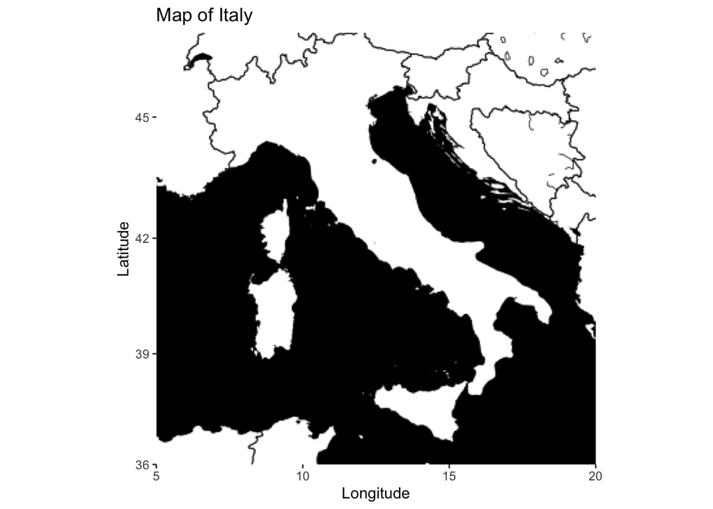

```r
library(ggmap)
#map of italy
italy <- c(left = 5, bottom = 36, right = 20, top = 47)
map <- get_stamenmap(italy, zoom = 5, maptype = "toner-background")
ggmap(map) + labs(x = "Longitude", y = "Latitude", title = "Map of Italy")
```

2. (15pts) In this part, you’ll create, for the country of your choice, a map with points corresponding to the location of each airport, sized and colored by `sqrt(flights)` at that airport. Then, you’ll interpret the map. Thus, for this part, please do the following:
- Define a subset of the `airportD` dataset that only contains airports within your map in Part A. Note that, in Part A, you had to specify minimum/maximum latitude and longitude coordinates; so, you’ll have to exclude airports that are outside that minimum/maximum latitude and longitude range.

```r
airportD.italySubset = subset(airportD,
                              lon >= 5 & lon <= 20 & lat >= 36 & lat <= 47)
```

- After you’ve defined your subset, make the desired map *using your subset*: The same map as Part A, but with points corresponding to the location of each airport, sized and colored by `sqrt(flights)` at that airport, where `flights` is the number of departing flights. Be sure that your color and size scheme makes sense for your data - so, you’ll have to do more than just copy-and-paste the Lecture 19 `R` demo code! In particular, **do not use the “Spectral” color palette within `scale_color_distiller()`** (but you can use any other color palette/scheme you want, as long it is sensible for your data).

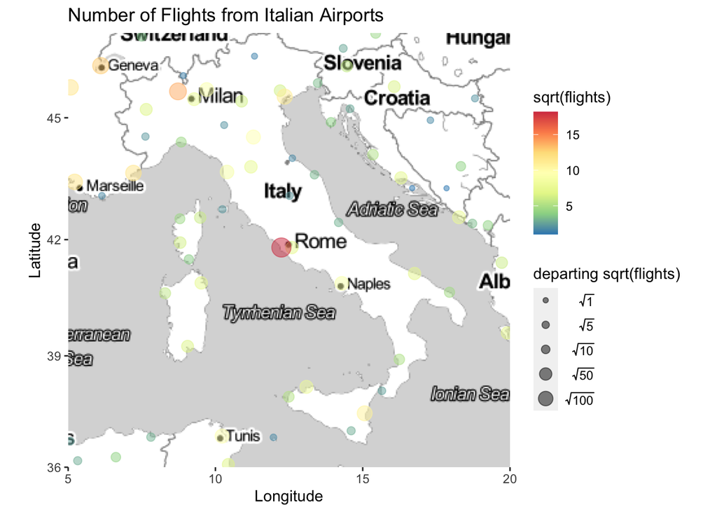

```r
#For this part, we're deciding to use "toner-lite" in order
#to see some of the city names:
map <- get_stamenmap(italy, zoom = 5, maptype = "toner-lite")

ggmap(map) +
geom_point(aes(x = lon, y = lat,
               size = sqrt(flights), color = sqrt(flights)),
          data = airportD.italySubset, alpha = .5) +
scale_size_area(breaks = sqrt(c(1, 5, 10, 50, 100)),
labels = c(expression(sqrt(1)), expression(sqrt(5)), expression(sqrt(10)), expression(sqrt(50)), expression(sqrt(100))),
name = "departing sqrt(flights)") +
scale_color_distiller(palette = "Spectral") +
  labs(x = "Longitude", y = "Latitude",
       title = "Number of Flights from Italian Airports")
```

- After you make your map, summarize the main observations you can make from your map in 1-3 sentences.

*We can see that most Italian airports are along the coast (especially in the south). Unsurprisingly, the airports with the most flights are near Rome and Milan. Interestingly, there aren’t that many airports with a low number of flights; most airports have a moderate number of flights, suggesting that Italy doesn’t have that many airports, but most of these airports are well-attended.*

3. (15pts) Now we’ll consider **kriging**, where we’ll make a map of estimated `sqrt(flights)` values from a statistical model. The goal of this problem is to create the same map in Part B, but with contour lines for *estimated* `sqrt(flights)` instead of points for *observed* `sqrt(flights)`. In other words, your goal is to make the the same type of map as the very last plot in the Lecture 19 `R` demo, except (1) without points for observed `sqrt(flights)`, and (2) for the country of your choice instead of the US.

To make the desired map, follow these steps (and be sure to include your code when performing these steps):

- Using the subset of `airportD` you visualized in Part B, fit the following statistical model:

```r
loessModel = loess(sqrt(flights) ~ lon * lat, data = airportD.italySubset,
    control=loess.control(surface="direct"))
```

All you have to do is uncomment the above line of code and fill in the question mark with the subset of `airportD` you visualized in Part B. Note that this subset should contain all airports within the minimum/maximum latitude and longitude range you visualized in Parts A and B.

- Create a grid of latitude and longitude points that you’ll use to generate estimated `sqrt(flights)`. Specifically, modify the following code (which was used in the Lecture 19 `R` demo):

```r
latGrid = seq(36, 47, by = 1)
lonGrid = seq(5, 20, by = 1)
lonLatGrid = data.frame(expand.grid(lonGrid, latGrid))
names(lonLatGrid) = c("lon", "lat")
```

You’ll have to specify the minimum/maximum latitude and longitude coordinates `minLat`, `maxLat`, `minLon`, and `maxLon` (you already specified these when making the map in Part A). See the Lecture 19 `R` demo if you’re unsure what this code does. Also: If the country you chose is unusually small, you can set `by = 0.1`; if the country you chose is unusually large, you can set `by = 2`. However, `by = 1` and `by = 1` should work well for most countries; ultimately, we just want to create a grid of latitude/longitude combinations.

- Generate predicted values from `loessModel`; all you have to do is uncomment this code:

```r
loessPred = predict(loessModel, lonLatGrid)
loessPred.df = data.frame(cbind(lonLatGrid, loessPred))
```

If this code doesn’t run, that means you made a mistake in the first two tasks. Again, see Lecture 19 `R` demo if you’re unsure what this code is doing.

- Finally, create the desired map: The same map as Part A, but with contour lines displaying `loessPred` within `loessPred.df`. **Do not** display points for individual airports (as I did in the Lecture 19 `R` demo). Thus, you only need to use `ggmap()` to create your map, and `geom_contour_filled()` to draw your contour lines. You should end up with a map that looks similar to the very last plot in the Lecture 19 `R` demo, except (1) without points for observed `sqrt(flights)`, and (2) for the country of your choice instead of the US.

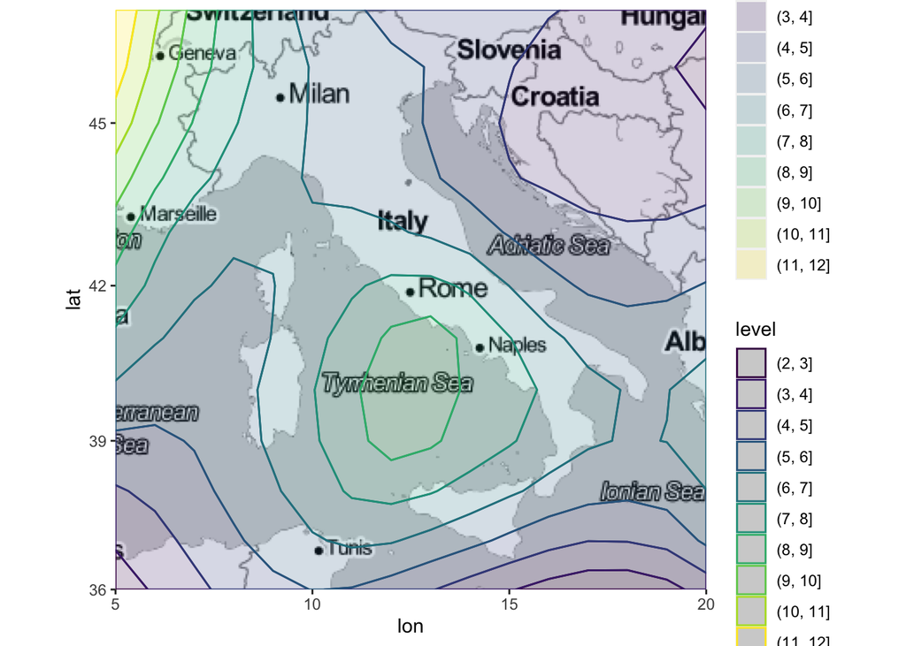

```r
ggmap(map) +
geom_contour_filled(data = loessPred.df, binwidth = 1,
               aes(x=lon,y=lat,z=loessPred, color = ..level..),
               alpha = 0.2)
```

After you’ve made your map, discuss in 1-4 sentences if the predictions displayed on your map make sense in terms of where there are “high `sqrt(flights)` predictions” and “low `sqrt(flights)` predictions.” For example, in the last plot of the Lecture 19 `R` demo, we discussed how predictions on the far left of that plot did not make sense, because it predicted a high number of flights in the middle of the Pacific ocean. On the other hand, it also predicted a high number of flights on the east and west coast of the US, which *did* make sense. I’m asking you to do a similar discussion for your map here. It might be helpful to look back to your map in Part B when discussing your map here.

*In some ways the predictions visualized in the map do not make sense: Most obviously, it seems like the model is estimating that there is a large number of flights in the middle of the Tyrrhenian Sea, which doesn’t make sense. Looking back at Part B, this is likely because there are a lot of flights immediately around the Tyrrhenian Sea (e.g., in Roman and the Italian islands), and thus the model inappropriately interpolated that there must also be many flights in the middle of the Tyrrhenian Sea. However, the model is at least estimating that there aren’t many flights in Slovenia and Croatia, while there are a higher number of flights in Italy and the Northwestern part of the map (towards Switzerland and France), which does make sense given what we saw in Part B. In short, it seems like our model is presenting sensible results for large land masses, but not as much for large bodies of water.*

# Problem 2: Choropleth Maps of Unemployment Rates (60 points)

This problem will ask you to make a couple of different choropleth maps; one map will display state-level information, and one plot will display county-level information. This will require you to do some basic data manipulation and aggregation, which is a very common skill to utilize in spatial data specifically and data science in general.

1. (5pts) Before we dig into the data and start making plots, please read [this short article](https://www.washingtonpost.com/news/wonk/wp/2016/04/11/the-dirty-little-secret-that-data-journalists-arent-telling-you/), which discusses a “[dirty little secret](https://www.youtube.com/watch?v=gPDcwjJ8pLg) that data journalists aren’t telling you” about choropleth maps. After you read the article, discuss in 2-4 sentences what you learned from the article, and mention at least one specific `R` function you can use to reflect what you learned from the article when making choropleth maps.

*From the article, we can see that seemingly rational methods of data visualization may not be the most effective way of presenting data. Even though dividing up a full range of data for a variable into equally sized bins might seem like a good idea, this method can be misleading if there are several extreme outliers or if a small number of bins have a disproportionately large/small number of observations. When considering how to visualize big distinctions in the data, like positive versus negative growth, it is often useful to use a bivariate color distribution to emphasize the distinction compared to using a single color gradient. More generally, it’s worthwhile to think carefully about the color scheme we use in our maps - color schemes should be easy to read (i.e., it should be easy to differentiate high-value regions from low-value regions) while also not being misleading (e.g., the same color shouldn’t represent meaningfully different values, such as positive and negative values having the same color). The `R` function `scale_fill_gradient2()` gives us a lot of flexibility for implementing color schemes, and we should use this function carefully.*

2. (20pts) In this problem, we will be working with data from the [2015 American Community Survey](https://www.census.gov/programs-surveys/acs); this dataset was obtained [from Kaggle](https://www.kaggle.com/census/2015-american-community-survey) and then simplified for the purposes of this homework.

```r
#load the rent data
acs = read.csv("https://raw.githubusercontent.com/zjbranson/315Fall2021/main/acs2015_county_data.csv")
```

This dataset contains some demographic information about every county in the United States. We will focus on the `Unemployment` variable, which denotes the unemployment rate (in terms of percentage) for each county. For this part in particular, the goal is to make a map of the 48 contiguous states of the US (i.e., all the states excluding Alaska and Hawaii), where each state is colored by its average unemployment rate.

For this part, you must do the following tasks:

1. Create a choropleth map showing the average unemployment rate **at the state level.** Your map should include the 48 contiguous US states as well as Washington D.C. To define the average unemployment rate for each state, just take the simple average across all counties in that state. When making your map, use an appropriate three-color gradient (as we saw in lecture and the Lecture19 `R` demo), but don’t use the same colors that were used in the Lecture19 `R` demo.

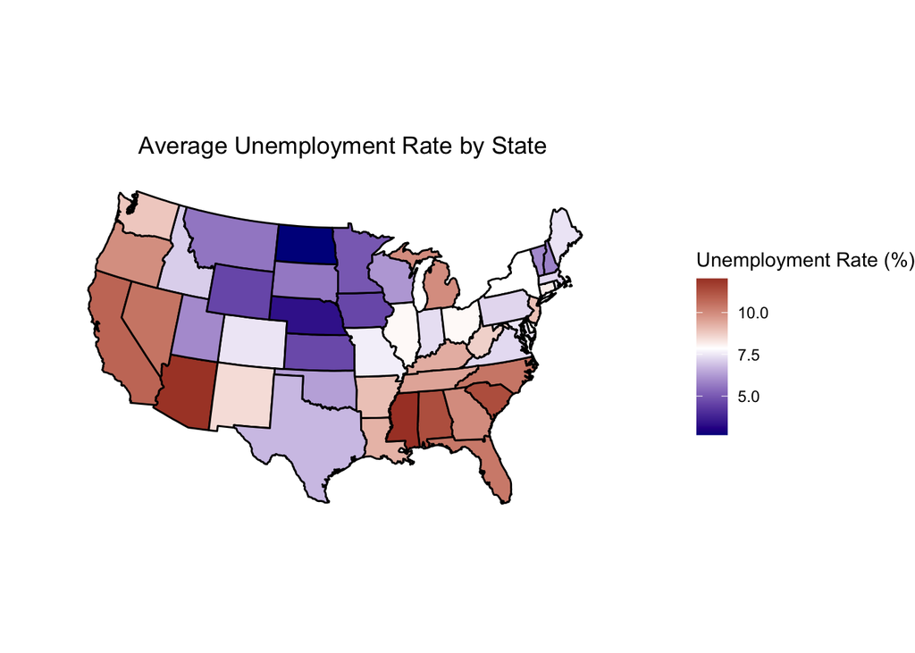

```r
#First we get border information for all states
state.data = map_data("state")

#Now we'll filter out Alaska, Hawaii, and Puerto Rico from the acs data
acs = subset(acs, State != "Alaska" & State != "Hawaii" & State != "Puerto Rico")

#Compute the simple average across counties
library(tidyverse)
acs.stateMean = acs %>% group_by(State) %>%
  summarize(meanUnemployment = mean(Unemployment) )

#In order to match the state data, we need to convert
#the state name to lower case in the ACS dataset.
acs.stateMean$State = tolower(acs.stateMean$State)

#Now we can merge the two datasets
acs.stateMean.merged = state.data %>% left_join(acs.stateMean, by = c("region" = "State"))

# Plot of states, colored by average unemployment rate
ggplot(acs.stateMean.merged) +
  geom_polygon(aes(x = long, y = lat, group = group, fill = meanUnemployment),
               color = "black") +
  scale_fill_gradient2(high = "darkred", low = "darkblue",
                       mid = "white", midpoint = median(acs.stateMean$meanUnemployment)) +
  theme_void() +
  coord_map("polyconic") +
  labs(title = "Average Unemployment Rate by State",
       fill = "Unemployment Rate (%)") +
  theme(plot.title = element_text(hjust = 0.5))
```

*[Note that, to color the map, we set `midpoint` equal to the median of the outcome variable, which is one common choice for color schemes.]*

2. After you’ve made your graph, describe the graph in 1-4 sentences, pointing out any interesting features of the spatial distribution of average unemployment rate that you see.

*We see that, generally, the unemployment rate is fairly low (around 6% or below) in the center part of the country (especially the upper midwest, like Nebraska, the Dakotas, and surrounding states), whereas the unemployment is fairly high (around 8% and above) on the west coast and southeastern part of the US. Meanwhile, more moderate unemployment rates are found in the northeastern and mid-Atlantic parts of the US.*

Thus, for this part, all you need to do is write code that produces the desired map, and then write your interpretation of the map. However, making the map will consist of several tasks, some of which were discussed in lecture and the `R` demo. As a hint, here are the broad tasks that you must complete to make the desired map:

- Your map only needs to include the 48 continguous US states and Washington D.C. Meanwhile, the `acs` dataset also contains information about Alaska, Hawaii, and Puerto Rico. So, create a subset of the `acs` data that excludes Alaska, Hawaii, and Puerto Rico.
- Compute the average unemployment rate for each state, and store this in a new dataset. The goal is to create a new dataset with one row per state and the average unemployment rate as a column. There are many ways to do this, but one way that might be helpful (and that we’ve discussed several times in class) is to use the `group_by()` and `summarize()` functions within the `dplyr` library.
- To create your map, you’ll need data on the state borders in the US. So, be sure to define a dataset contain state border information using `map_data("state")` (as discussed in lecture and the R demo). Note that this dataset contains Washington D.C. and excludes Alaska, Hawaii, and Puerto Rico, so you don’t need to do any further subsetting on this dataset.
- Match the dataset from the second bullet point (the average unemployment rate dataset) with the dataset from the third bullet point (the state borders dataset). Note that `acs` lists states with capital letters, while `map_data("state")` lists the states all-lowercase letters. Thus, you’ll have to use the `tolower()` function on the `acs` dataset before you can match the two datasets. To match the datasets, you can use `left_join()` (as demonstrated in the R demo) or `merge()`.
- Plot the choropleth map of the state-level areal data. Be sure to choose a color scheme that seems appropriate for the data.
- Remember to, after you’ve made your graph, describe the graph in 1-4 sentences, pointing out any interesting features of the spatial distribution of average unemployment rate.
3. (10pts) In Part B, you made a choropleth map of the average unemployment rate for each state, where “average” is defined as just the simple average across all counties in that state. However, different counties will likely have very different population sizes, and thus it might not be appropriate to take just a simple average across all counties. Instead, we can consider a [*weighted* average](https://en.wikipedia.org/wiki/Weighted_arithmetic_mean), where we upweigh counties with large population sizes and downweigh counties with low population sizes. In this case, the weighted average for a given state is defined as:

$$\frac{\sum_{i=1}^n P_i U_i }{\sum_{i=1}^n P_i }$$

where $P_i$ is the `TotalPop` for county $i$ and $U_i$ is the `Unemployment` for county $i$. Thus, when you computed the simple average in Part B, you instead set $P_i = 1$ in the above definition of the weighted mean, thereby giving each county equal weight when computing the average.

For this part, again make a choropleth map showing the average unemployment rate **at the state level.** However, define average unemployment rate as the *weighted* average across counties, instead of the simple average. To do this, you should be able to just copy-and-paste your code from Part B, alter it slightly, and define the average unemployment rate as a weighted average instead of a simple average.

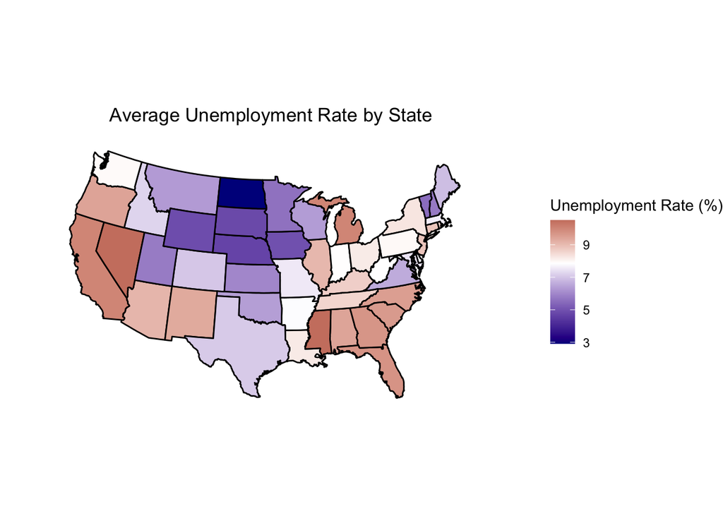

```r
#Compute the weighted mean across counties:
acs.stateWeightedMean = acs %>% group_by(State) %>%
  summarize(meanUnemployment = sum(TotalPop*Unemployment)/sum(TotalPop) )

#In order to match the state data, we need to convert
#the state name to lower case in the ACS dataset.
acs.stateWeightedMean$State = tolower(acs.stateWeightedMean$State)

#Now we can merge the two datasets
acs.stateWeightedMean.merged = state.data %>% left_join(acs.stateWeightedMean, by = c("region" = "State"))

# Plot of states, colored by average unemployment rate
ggplot(acs.stateWeightedMean.merged) +
  geom_polygon(aes(x = long, y = lat, group = group, fill = meanUnemployment),
               color = "black") +
  scale_fill_gradient2(high = "darkred", low = "darkblue",
                       mid = "white", midpoint = median(acs.stateMean$meanUnemployment)) +
  theme_void() +
  coord_map("polyconic") +
  labs(title = "Average Unemployment Rate by State",
       fill = "Unemployment Rate (%)") +
  theme(plot.title = element_text(hjust = 0.5))
```

**Hint**: It should be easy to code the above mathematical definition of a weighted mean. However, you could also use the `weighted.mean()` function.

After you’ve made your graph, compared and contrast this map in Part C with the map you made in Part B. In particular: What attributes of the maps are similar, and what attributes are different?

*First, note that we kept the `midpoint` argument the same in this map (compared to the Part B map) to make comparisons easier. The overall trends of this map are quite similar to the trends in the previous map: Low unemployment rates tend to be in the central part of the US, and high unemployment rates tend to be on the west coast and southeastern parts of the US. The main difference we see in this plot is that it seems like there are less extreme unemployment rates across states - for example, unemployment rates in the west coast and southeastern parts of the US, though still high, are less high than what we saw in Part B. We can also see this just by comparing the upper end of the color scales in both plots (in this plot it only reaches up to about 10%, whereas in the Part B plot it reaches to about 12%). [This kind of “shrinking” to less extreme numbers is common for weighted averages, because now small counties that likely have extreme unemployment rates are given less weight when computing the overall state average.]*

4. (15 points) Now we will complement the findings you made with the state-level map in **Part B** (just using a simple average) with a statistical analysis. In other words: Use a statistical analysis to determine if the “interesting features” you noted in Part B are “statistically significant” in some sense. For this part, you may perform **one** of the two analysis techniques (choose whichever you prefer):
- Create a dendrogram for the state-level data, and compare clustering from the dendrogram with geographic clustering. To illustrate “geographic clustering” in your dendrogram, you should make sure the leaf labels correspond to state names; and ideally, leaf labels should be colored by geographic region using `state.region`, as used in the Lecture19 `R` demo (and available in the `datasets` library). Note that `state.region` is ordered in the same way as `state.name`, which **does not** contain Washington, D.C. You’ll have to make your own region label for Washington, D.C. (I would choose “South”). Coloring the leaf labels may be the most challenging part; if you cannot do this, you can turn in a dendrogram without colored leaf labels, and you’ll receive a small point deduction.
- Perform a visual randomization test. For the sake of assessing the randomization, simply assess it yourself, rather than showing it to someone else (as discussed in the Lecture19 `R` demo.)

We discussed these methods in lecture, and the Lecture19 `R` demo demonstrates how to do these approaches. In your answer for this part, include your analysis, and in 2-4 sentences, interpret your analysis and discuss how it provides additional information to the graph you made in Part B.

*In this part, we will show how to complement our findings about the state-level map in Part B with a dendrogram and a visual randomization test. You only had to do one of these two approaches for your submission, but I wanted to demonstrate both approaches here.*

*First we will make a dendrogram, where leaf labels list the state and are colored by a geographic region of the US. To make a dendrogram based on the unemployment rate, we follow the same procedure we’ve seen before: Scale the outcome variable (in this case, unemployment rate), create a distance matrix, run hierarchical clustering, and create a dendrogram.*

```r
#scaling our outcome variable
unemp.scaled = acs.stateMean$meanUnemployment/sd(acs.stateMean$meanUnemployment)
#creating our distance matrix
unemp.dist = dist(unemp.scaled)
#run hierarchical clustering
unemp.hc = hclust(unemp.dist, method = "complete")
#convert to a dendrogram type object
unemp.dend = as.dendrogram(unemp.hc)
```

*Using the `set()` function, we can also easily change the leaf labels to the names of each state:*

```r
library(dendextend)
unemp.dend = set(unemp.dend, "labels", acs.stateMean$State, order_value = T)
```

*At this point, we can plot an interesting dendrogram, with leaf labels corresponding to each state:*

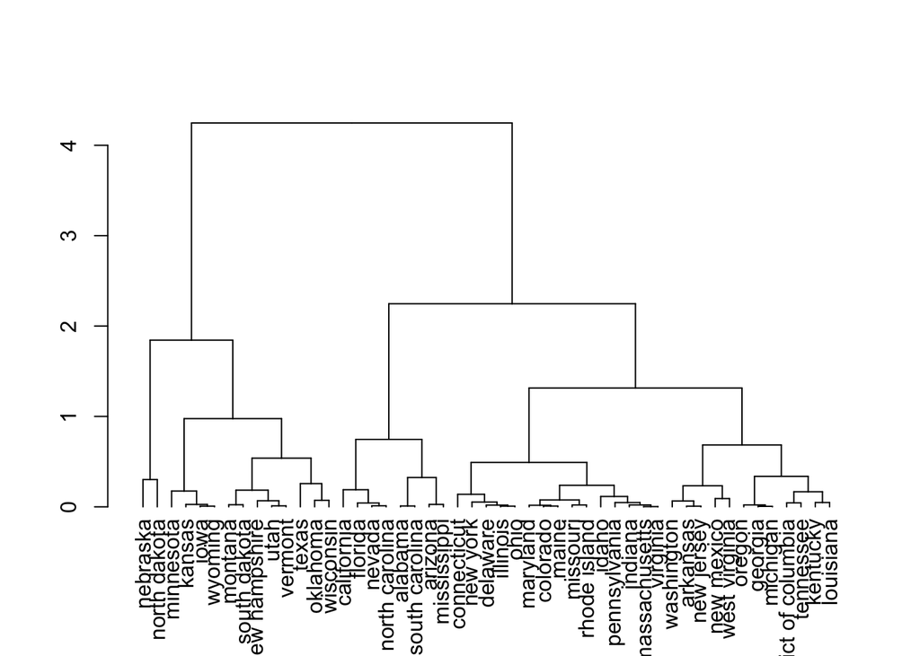

```r
plot(unemp.dend)
```

*However, it is difficult to ascertain geographic regions from the leaf labels alone: We have to go through every leaf label and think about whether the states clustered together are geographically close together (which may be especially hard to do if you’re not super familiar with US geography).*

*To make the dendrogram more informative, we will color the leaf labels by geographic region. In particular, we will use the `state.region` object available in the `datasets` library, as we used in the R demo:*

```r
state.region
```

```
##  [1] South         West          West          South         West
##  [6] West          Northeast     South         South         South
## [11] West          West          North Central North Central North Central
## [16] North Central South         South         Northeast     South
## [21] Northeast     North Central North Central South         North Central
## [26] West          North Central West          Northeast     Northeast
## [31] West          Northeast     South         North Central North Central
## [36] South         West          Northeast     Northeast     South
## [41] North Central South         South         West          Northeast
## [46] South         West          South         North Central West
## Levels: Northeast South North Central West
```

*An important thing to note is that the `state.region` vector is ordered in a very specific way, according to how states are listed in `state.name`. To understand this, we’ll create a “reference dataset” with `state.region` and `state.name`:*

```r
regionRef = data.frame(State = state.name, region = state.region)
regionRef[1:10,]
```

```
##          State    region
## 1      Alabama     South
## 2       Alaska      West
## 3      Arizona      West
## 4     Arkansas     South
## 5   California      West
## 6     Colorado      West
## 7  Connecticut Northeast
## 8     Delaware     South
## 9      Florida     South
## 10     Georgia     South
```

*Note that Washington, D.C. is not listed in the above data.frame. Nonetheless, we can still match this dataset to the `acs.stateMean` dataset, and then create a region variable for Washington, D.C. ourselves. Below we match these two datasets together, being sure to first convert `State` to lowercase letters in `regionRef`:*

```r
regionRef$State = tolower(regionRef$State)
acs.stateMean = left_join(acs.stateMean, regionRef, by = c("State" = "State"))
```

*Note that, as a result, there is no label for Washington, D.C., and so we create one ourselves:*

```r
acs.stateMean[1:10,]
```

```
## # A tibble: 10 × 3
##    State                meanUnemployment region
##    <chr>                           <dbl> <fct>
##  1 alabama                         11.3  South
##  2 arizona                         12.0  West
##  3 arkansas                         8.98 South
##  4 california                      10.8  West
##  5 colorado                         7.46 West
##  6 connecticut                      8.16 Northeast
##  7 delaware                         7.93 South
##  8 district of columbia             9.6  <NA>
##  9 florida                         10.4  South
## 10 georgia                          9.97 South
```

```r
acs.stateMean[acs.stateMean$State == "district of columbia",]$region = "South"
```

*Finally, we can plot our leaf-colored dendrogram:*

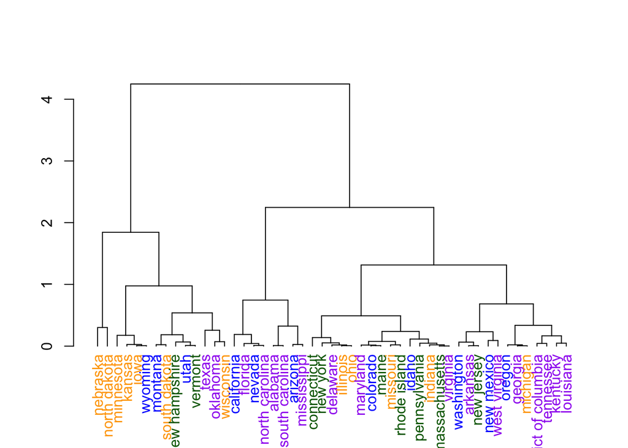

```r
#Now we can create colors for each region,
#and then color the dendrogram by region.
state.region.colors = ifelse(acs.stateMean$region == "Northeast", "darkgreen",
                             ifelse(acs.stateMean$region == "South", "purple",
                                    ifelse(acs.stateMean$region == "North Central", "orange", "blue")))
#Set the leaf labels according to the above colors:
unemp.dend = set(unemp.dend, "labels_colors", state.region.colors, order_value = T)
#plot the dendrogram
plot(unemp.dend)
```

*From the above dendrogram, it appears that geographic clusters (e.g., “Northeast”, “South”, “North Central”, and “West”) are only somewhat associated with the clusters automatically detected by the dendrogram. The far left clusters are clearly upper midwest states (Nebraska, the Dakotas, Minnesota, Kansas, Iowa, Wyoming, Montana), but there is also an odd mix of other states in one of the left clusters (New Hampshire, Utah, Vermont, Texas, Oklahoma, and Wisconsin). Meanwhile, the middle-left cluster appears to be a mix of coastal southern states (Florida, the Carolinas, Alabama) and western states (California, Nevada, and Arizona), while the middle-right cluster is an odd mix of states across the US. Finally, the right-hand cluster seems to be mostly southern states, but with a few other states (Michigan, Oregon, New Mexico, New Jerksey, and Washington) included as well. In summary, there seems to be some association between geographic clusters and the clusters automatically dedicated with the dendrogram, but there certainly is not a clean one-to-one alignment.*

*We could also perform a visual randomization test, as we do below.*

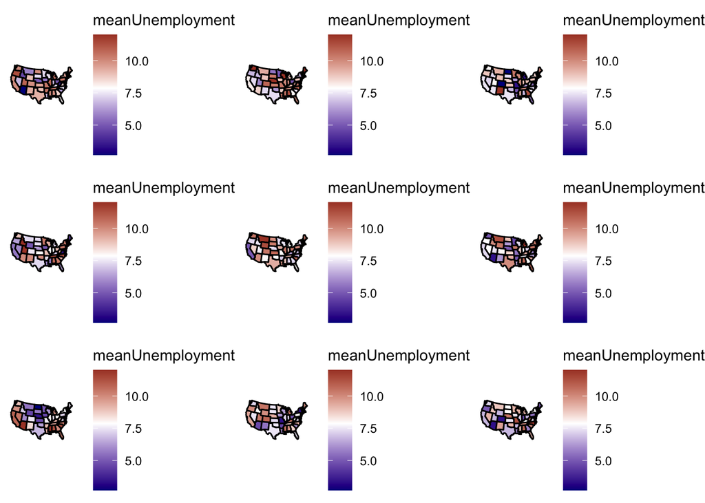

```r
#It'll be helpful to write a function that automatically
#makes a ggplot for us.
#This is literally the same code we used to generate the
#original areal map above, but for any dataset called "data".
getStateMap.unemp = function(data){
  plot = ggplot(data) +
  geom_polygon(aes(x = long, y = lat, group = group, fill = meanUnemployment),
               color = "black") +
  scale_fill_gradient2(high = "darkred", low = "darkblue",
                       mid = "white", midpoint = 7.86) +
  theme_void() +
  coord_map("polyconic")
  return(plot)
}

#Now we're going to permute (i.e., "shuffle") the outcomes a few times.
#number of randomizations/permutations/shuffles:
rands = 9

plotList = list(length = rands)
for(r in 1:rands){
  #create a "randomized" dataset
  acs.stateMean.merged.rand = acs.stateMean.merged
  #shuffle the outcomes
  acs.stateMean.merged.rand$meanUnemployment = sample(acs.stateMean.merged.rand$meanUnemployment)
  #create the plot and store it
  plotList[[r]] = getStateMap.unemp(acs.stateMean.merged.rand)
}

#pick a random entry of plotList to be the "real" plot
plotList[[sample(1:rands, size = 1)]] = getStateMap.unemp(acs.stateMean.merged)

#plot all the plots together
library(gridExtra)
grid.arrange(plotList[[1]], plotList[[2]], plotList[[3]],
             plotList[[4]], plotList[[5]], plotList[[6]],
             plotList[[7]], plotList[[8]], plotList[[9]],
             nrow = 3)
```

*I would say that, arguably, the “real” map still stands out, because it has some distinct clustering of blue values (i.e., low unemployment) in the center of the map, and we don’t see this kind of clustering (just by chance) in the other maps. Thus, I would argue that this randomization suggests that the unemployment rates are significantly non-random across states, i.e., there is a geographic relationship among unemployment rates. [However, you may well have come up with a different conclusion, depending on the maps you produced just by chance from your randomization test.].*

5. (10pts) Now let’s recognize that the `acs` data contains information about every *county* in the US, but so far we’ve only plotted data for each state. Thus, as one final graph, make a choropleth map showing the unemployment rate at the county level, and again use an appropriate three-color gradient. When making your graph, do not color the county borders; otherwise, the unemployment rate data will be difficult to see.

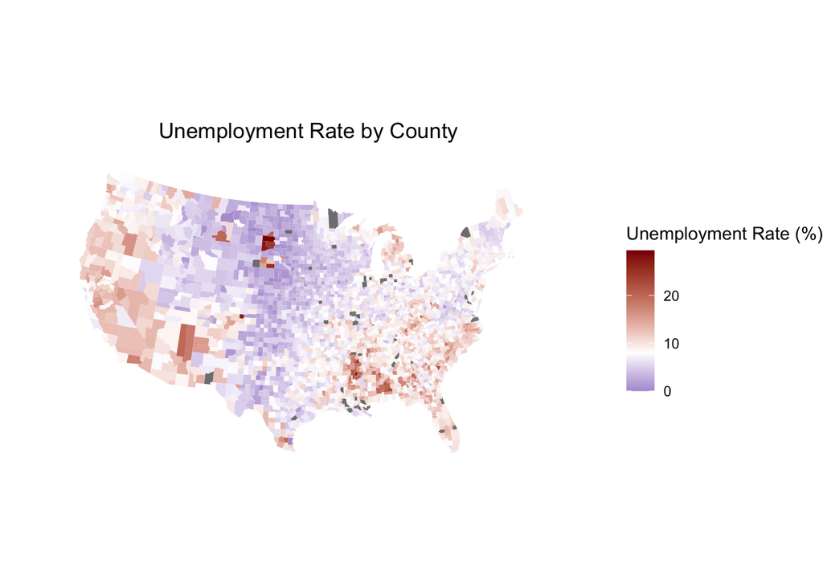

```r
#First get county border data.
county.data = map_data("county")

#We need to change the states and counties to lowercase in the ACS dataset
acs$State = tolower(acs$State)
acs$County = tolower(acs$County)

#Now we can merge the two datasets
acs.merged = county.data %>% left_join(acs,
  by = c("region" = "State", "subregion" = "County"))

ggplot(acs.merged) +
  geom_polygon(aes(x = long, y = lat, group = group, fill = Unemployment)) +
  scale_fill_gradient2(high = "darkred", low = "darkblue",
                       mid = "white", midpoint = median(acs.merged$Unemployment, na.rm = TRUE)) +
  theme_void() +
  coord_map("polyconic") +
  labs(title = "Unemployment Rate by County",
       fill = "Unemployment Rate (%)") +
  theme(plot.title = element_text(hjust = 0.5))
```

**Hint**: The workflow for this problem is exactly the same as the workflow for Part B, except now you have to use `map_data("county")` instead of `map_data("state")`; note that each county will be contained in the `subregion` variable, all with lowercase letters. The workflow should actually be easier for this problem, because you don’t need to compute average unemployment rates. However, when matching the two datasets (`acs` and `map_data("county")`), be sure to match on `State` **and** `County`. Your map will have some gray colors, denoting missing values at the county level, and that’s okay. For this part, all you have to do is make the map.